# TOPIC: EDA-Suicide Rate Analysis

1.1 LOADING THE LIBRARIES

```python
import numpy as np
import pandas as pd
import matplotlib.pyplot as plt
import seaborn as sns
```

1.2 IMPORTING THE DATASETS

```python
data=pd.read_csv('master.csv')
```

1.3 Check the data head()

```python
data.head()
```

|  | country | year | sex | age | suicides_no | population | suicides/100k pop | country-year | HDI for year | gdp_for_year ($) | gdp_per_capita ($) | generation |
| --- | --- | --- | --- | --- | --- | --- | --- | --- | --- | --- | --- | --- |
| 0 | Albania | 1987 | male | 15-24 years | 21 | 312900 | 6.71 | Albania1987 | NaN | 2,156,624,900 | 796 | Generation X |
| 1 | Albania | 1987 | male | 35-54 years | 16 | 308000 | 5.19 | Albania1987 | NaN | 2,156,624,900 | 796 | Silent |
| 2 | Albania | 1987 | female | 15-24 years | 14 | 289700 | 4.83 | Albania1987 | NaN | 2,156,624,900 | 796 | Generation X |
| 3 | Albania | 1987 | male | 75+ years | 1 | 21800 | 4.59 | Albania1987 | NaN | 2,156,624,900 | 796 | G.I. Generation |
| 4 | Albania | 1987 | male | 25-34 years | 9 | 274300 | 3.28 | Albania1987 | NaN | 2,156,624,900 | 796 | Boomers |

1.4 Check the data.describe()

```python
data.describe()
```

|  | year | suicides_no | population | suicides/100k pop | HDI for year | gdp_per_capita ($) |
| --- | --- | --- | --- | --- | --- | --- |
| count | 27820.000000 | 27820.000000 | 2.782000e+04 | 27820.000000 | 8364.000000 | 27820.000000 |
| mean | 2001.258375 | 242.574407 | 1.844794e+06 | 12.816097 | 0.776601 | 16866.464414 |
| std | 8.469055 | 902.047917 | 3.911779e+06 | 18.961511 | 0.093367 | 18887.576472 |
| min | 1985.000000 | 0.000000 | 2.780000e+02 | 0.000000 | 0.483000 | 251.000000 |
| 25% | 1995.000000 | 3.000000 | 9.749850e+04 | 0.920000 | 0.713000 | 3447.000000 |
| 50% | 2002.000000 | 25.000000 | 4.301500e+05 | 5.990000 | 0.779000 | 9372.000000 |
| 75% | 2008.000000 | 131.000000 | 1.486143e+06 | 16.620000 | 0.855000 | 24874.000000 |
| max | 2016.000000 | 22338.000000 | 4.380521e+07 | 224.970000 | 0.944000 | 126352.000000 |

1.5 Cleaning check if there is missing data Check the Columns

```python
data.columns
```

```
Index(['country', 'year', 'sex', 'age', 'suicides_no', 'population',
       'suicides/100k pop', 'country-year', 'HDI for year',
       ' gdp_for_year ($) ', 'gdp_per_capita ($)', 'generation'],
      dtype='object')
```

1.6 Checking the shape of data

```python
data.shape
```

```
(27820, 12)
```

1.7 Count the datatypes

```python
data.dtypes.value_counts()
```

```
object     6
int64      4
float64    2
dtype: int64
```

1.8 Check the data set information

```python
data.info()
```

```
<class 'pandas.core.frame.DataFrame'>
RangeIndex: 27820 entries, 0 to 27819
Data columns (total 12 columns):
 #   Column              Non-Null Count  Dtype
---  ------              --------------  -----
 0   country             27820 non-null  object
 1   year                27820 non-null  int64
 2   sex                 27820 non-null  object
 3   age                 27820 non-null  object
 4   suicides_no         27820 non-null  int64
 5   population          27820 non-null  int64
 6   suicides/100k pop   27820 non-null  float64
 7   country-year        27820 non-null  object
 8   HDI for year        8364 non-null   float64
 9    gdp_for_year ($)   27820 non-null  object
 10  gdp_per_capita ($)  27820 non-null  int64
 11  generation          27820 non-null  object
dtypes: float64(2), int64(4), object(6)
memory usage: 2.5+ MB
```

1.8 Checking the dataset missing values

```python
total_missing_check=data.isnull().sum().sort_values(ascending=False)    #Total number of Null values
total_missing_check
```

```
HDI for year          19456
generation                0
gdp_per_capita ($)        0
 gdp_for_year ($)         0
country-year              0
suicides/100k pop         0
population                0
suicides_no               0
age                       0
sex                       0
year                      0
country                   0
dtype: int64
```

```
             1.9  Create Frequency table for Age
```

```python
my_tab=pd.crosstab(index=data['age'], columns='Freq')
my_tab
```

| col_0 age | Freq |
| --- | --- |
| 15-24 years | 4642 |
| 25-34 years | 4642 |
| 35-54 years | 4642 |
| 5-14 years | 4610 |
| 55-74 years | 4642 |
| 75+ years | 4642 |

1.10 Bar plot to check Number of Suicides by top Countries

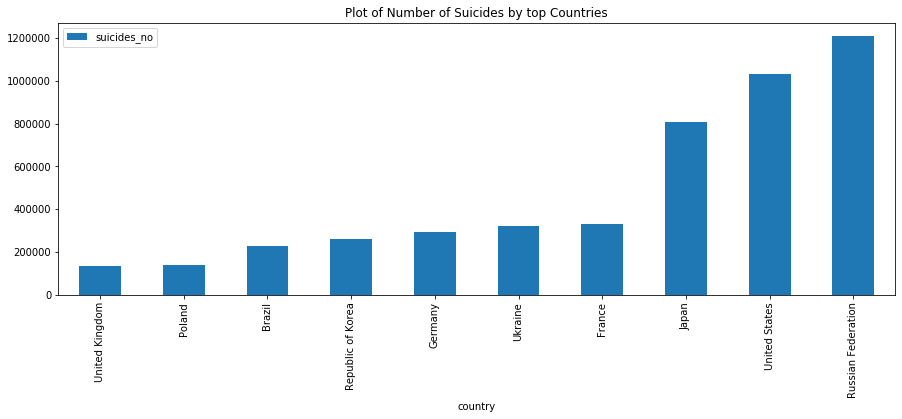

```python
data.groupby(by=['country'])['suicides_no'].sum().reset_index().sort_values(['suicides_no']).tail(10).plot(x='country',y='suicides_no',kind='bar', figsize=(15,5))
plt.title('Plot of Number of Suicides by top Countries')

plt.show()
```

Fig 1.0: Number of suicides by countries

1.11 Bar Plot for Number of suicides by Age

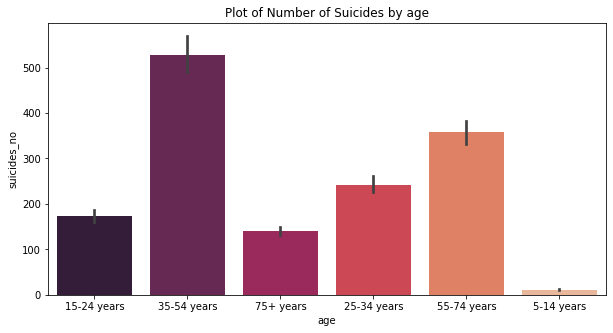

```python
plt.figure(figsize=(10,5))   #setting the figure size
ax=sns.barplot(x='age',y='suicides_no', data=data,  estimator= np.mean,ci=90, palette='rocket' )#barplot
plt.title('Plot of Number of Suicides by age')
```

Fig 2.0: Bar Plot of Number of suicides by Age

1.12 Bar Plot of Number of Suicides by Sex

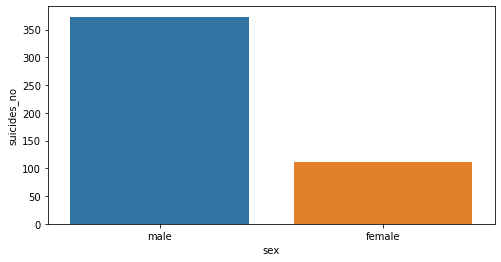

```python
plt.figure(figsize=(8,4))
ax = sns.barplot(x='sex',y='suicides_no', data=data,ci=None)
plt.show()
```

1.13 Bar plot of Number of Suicides vs generation

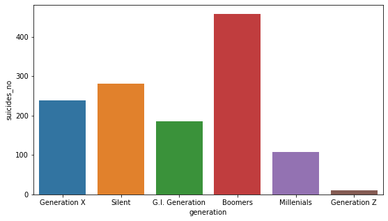

```python
plt.figure(figsize=(9,5))
ax= sns.barplot(x='generation', y='suicides_no', data=data,ci=None)
```

Interpretation:

- The suicides rate for Baby Boomers(People born after the second world war) seems to be high compared to the others.

1.14 Scatter Plot of Number of Suicides vs Population.

# This is a numerical vs numerical data, so, scatter plot will be a good preference.

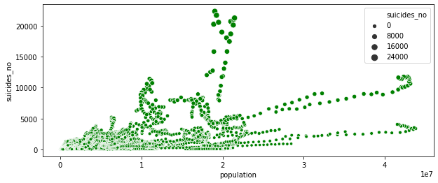

```python
figure=plt.figure(figsize=(10,4))
ax= sns.scatterplot(x='population',y='suicides_no', data=data,size='suicides_no',color='g') #scatter plot
```

In order to a more clearer picture to establish this relationship, we introduce a regression line.

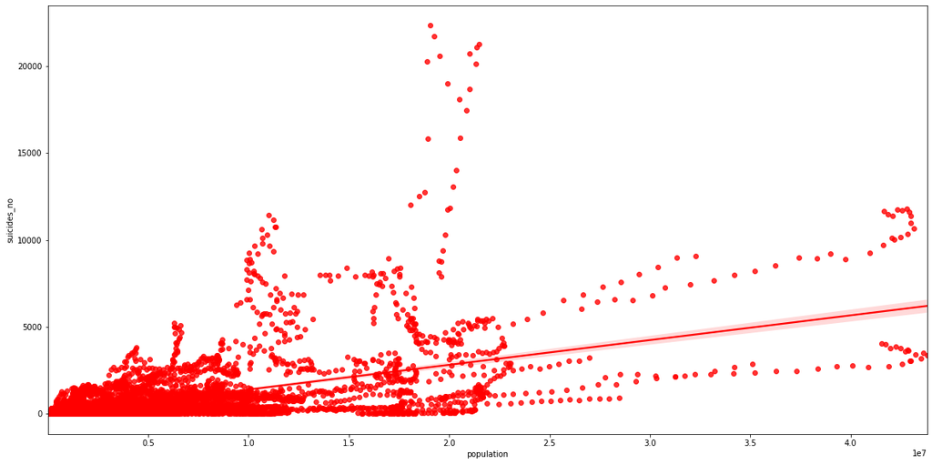

```python
figure=plt.figure(figsize=(20,10))
ax= sns.regplot(x='population',y='suicides_no', data=data,color='r') #scatter plot
```

Fig 3.0: Scatter Plot of Number of Suicides vs Population

We can also view this relationship lineraly, using a line plot

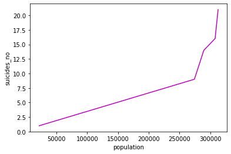

```python
x= sns.lineplot(x='population',y='suicides_no', data=data.head(),color='m')
```

1.15 Effects of GDP per capita on the suicide rates of a country We use a scatter plot: +Scatter plot Number of suicides/100k population vs GDP percapita

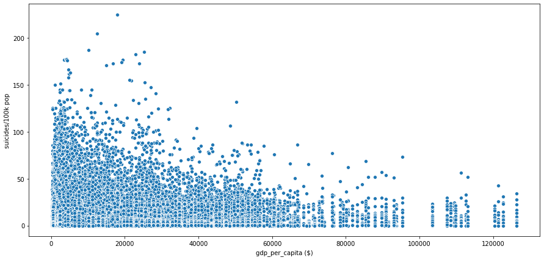

```python
plt.figure(figsize=(15,7))
sns.scatterplot(x='gdp_per_capita ($)', y='suicides/100k pop', data=data)  #scatter plot
plt.show()
```

Fig 4.0: Suicide rate vs GDP percapita +

We can use the Heatmap to check if there are any significant correlation among the two variables

Correlation among pairs of continous variables

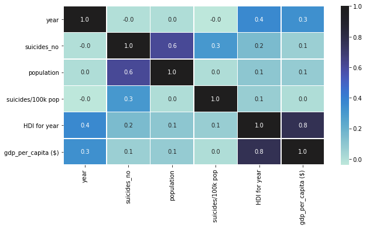

```python
plt.figure(figsize=(10,5))
sns.heatmap(data.corr(), annot=True, linewidths= 0.5, fmt='0.1f', center=1)
```

1.16 Bar plot to check Number of suicides by sex and age to generate a single plot

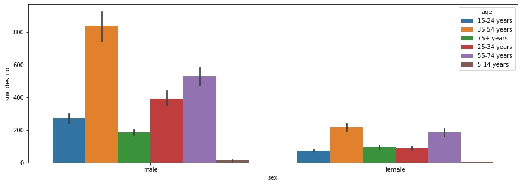

```python
plt.figure(figsize=(15,5))
sns.barplot(x='sex',y='suicides_no', data=data, hue='age')
plt.show()
```

Fig 5.0:Bar plot to check Number of suicides by sex

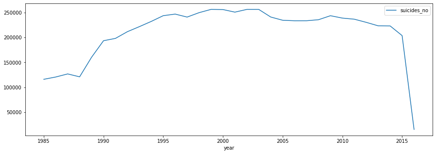

```python
data[['year','suicides_no']].groupby(['year']).sum().plot(figsize=(15,5))
```